# QTM_347_Homework_1_(2481976,_2511821,_2581225,_2558223)

```python
#pip install numpy
import numpy as np
```

**Question 1**

For each of parts (a) through (c), indicate whether we would generally expect the performance of a flexible machine learning method (e.g., neural network) to be better or worse than an inflexible method (e.g., linear regression). Justify your answer.

**PART A**

The sample size n is extremely large, and the number of predictors p is small.

A flexible method outperforms an inflexible method when there is a large n but small p. This is because flexible models require large amounts of data (large n) in order to model complex relationships without the concern of overfitting to a limited number of data points.

**PART B**

The number of predictors p is extremely large, and the number of observations n is small.

An inflexible method is better than a flexible method in this case because the flexible model may overfit to the small amount of data relative to the predictors p. With high p and small n, the SNR (signal to noise ratio) is low because there is a high amount of noise.

**PART C**

The relationship between the predictors and response is highly non-linear.

In this scenario, a flexible model would outperform an inflexible model because an inflexible model like linear regression has assumptions (i.e. a linear regression assumes a linear underlying structure). With a nonparametric, flexible model, these assumptions would no longer hold. The flexible model can better map to nonlinear data points.

**Question 2**

**PART A**

For K = 1 the closest neighbor is the point (24.39, 8.3) so K = 1 would be a predicted medv of **8.3**. For K = 5, the 5 closest neighbors are (24.39, 8.3), (25.68, 9.7), (24.16,14), (26.4,17.2), (23.6, 11.3) so K = 5 would be the average of 8.3, 9.7, 14, 17.2, and 11.3 --> predicted medv of **12.1**

**PART B**

For K = 1 the closest neighbor is (26.82,13.4) so K = 1 would have a predicted medv of **13.4** For K = 5, the 5 closest neighbors are (26.82,13.4) (26.4,17.2), (25.68,9.7), (24.39,8.3), (29.68,8.1) so K = 5 would be the average of 13.4, 17.2, 9.7, 8.3, and 8.1 so the predicted medv for K = 5 would be **11.34**

**PART C**

**PART D**

For K = 1 the closest neighbor is (26.82,1) so K = 1 would have a predicted medv of **1** For K = 5, the 5 closest neighbors are (26.82,1) (26.4,2), (25.68,0), (24.39,0), (29.68,0) so for K = 5 the predicted medv_cat for K = 5 would be **0**

**PART E**

If we increase K in KNN the model will be less flexible because as K increases the model gets closer to approaching a constant function. Visually, if you have a lower K like K = 1 the function would map to every individual point whereas when K is larger like K = 5 this gets closer to a constant function and eventually when K = n (in our case 10) then we get a constant function.

**PART F**

As K increases with KNN regression...

**Square Bias:** Bias increases with higher values of K because the model becomes closer to an inflexible constant function so is more likely to be further from the true values.

**Variance:** Variance decreases with higher values of K because when the model is again closer to this inflexible constant function there is less variability/ more consistency is the values (more constrained).

**Training MSE:** Increases as K increases because with K = 1 there would be a training MSE of 0 (because the models maps every training data point exactly into the model). However, when this value for K increases, we would have a larger training MSE because we are averaging across more points, so the average is further from the actual point.

**Test MSE:** Decreases with K to a certain extent because there is an optimal value for the Test MSE K paramater: A small K tends to overfit and too large of a K is "overgeneralized" and inflexible due to the bias-variance tradeoff we need to find a "in between".

**Irreducible Error:** This does not change with K because the Irreducible Error is constant regardless of the model f (i.e. differing models based on changing the paramater K would NOT change this error)

**Question 3**

In this problem, we are going to use simulated data sets to better understand how the square of bias, variance, irreducible error, and MSE vary with model flexibility.

**PART A**

```python
import numpy as np
import pandas as pd
np.random.seed(42)


def f(x):
  return x ** 5 - 2 * x ** 4 + x ** 3
def get_sim_data(f, sample_size=100, std=0.01):
  x = np.random.uniform(0, 1, sample_size)
  y = f(x) + np.random.normal(0, std, sample_size)
  df = pd.DataFrame({'x': x, 'y': y})
  return df
```

In this data set, what is the number of observations n and what is the number of features p (different powers of x are counted as different features)? Write out the model used to generate the data in equation form.

The number of observations is 100 and the number of features is 3.

$y = x^5 - 2x^4 + x^3$

**PART B**

```python
import numpy as np
from sklearn.preprocessing import PolynomialFeatures
from sklearn.linear_model import LinearRegression

data = get_sim_data(f)
x = data['x'].values.reshape(-1, 1)
y = data['y']
```

```python
def polynomial_print(d):
    poly = PolynomialFeatures(d)
    x_poly = poly.fit_transform(x.reshape(-1, 1))  # Ensure x is reshaped for sklearn

    model = LinearRegression()
    model.fit(x_poly, y)

    coefficients = model.coef_
    intercept = model.intercept_

    # Print the polynomial equation
    equation = f"y = {intercept:.4f}"
    for i, c in enumerate(coefficients[1:], start=1):  # Skip the first coef (bias)
        equation += f" + {c:.4f}x^{i}"

    print(f"Degree {d}: {equation}")



for d in range(16):
    polynomial_print(d)  # Example: Evaluate at x=0
```

```
Degree 0: y = 0.0162
Degree 1: y = 0.0058 + 0.0214x^1
Degree 2: y = -0.0212 + 0.1809x^1 + -0.1596x^2
Degree 3: y = -0.0087 + 0.0416x^1 + 0.1881x^2 + -0.2345x^3
Degree 4: y = 0.0008 + -0.1388x^1 + 0.9996x^2 + -1.4975x^3 + 0.6321x^4
Degree 5: y = -0.0007 + -0.0927x^1 + 0.6738x^2 + -0.6155x^3 + -0.3743x^4 + 0.4076x^5
Degree 6: y = -0.0044 + 0.0655x^1 + -0.9163x^2 + 5.7569x^3 + -12.3251x^4 + 10.9207x^5 + -3.5033x^6
Degree 7: y = -0.0058 + 0.1506x^1 + -2.0556x^2 + 12.0407x^3 + -29.5295x^4 + 35.6197x^5 + -21.2972x^6 + 5.0726x^7
Degree 8: y = -0.0094 + 0.4332x^1 + -6.9863x^2 + 48.0372x^3 + -164.0998x^4 + 314.7455x^5 + -345.9700x^6 + 203.1949x^7 + -49.3526x^8
Degree 9: y = -0.0117 + 0.6693x^1 + -12.3120x^2 + 98.4897x^3 + -413.1235x^4 + 1019.5602x^5 + -1531.5083x^6 + 1373.4969x^7 + -675.0105x^8 + 139.7444x^9
Degree 10: y = -0.0126 + 0.7925x^1 + -15.8698x^2 + 141.0204x^3 + -679.2822x^4 + 1992.4761x^5 + -3718.5378x^6 + 4435.8582x^7 + -3277.4223x^8 + 1367.7558x^9 + -246.7845x^10
Degree 11: y = -0.0097 + 0.2305x^1 + 4.7126x^2 + -162.5211x^3 + 1661.5761x^4 + -8671.7979x^5 + 26821.1572x^6 + -52045.1239x^7 + 64085.0891x^8 + -48656.8537x^9 + 20789.2386x^10 + -3825.7065x^11
Degree 12: y = -0.0128 + 1.1151x^1 + -35.3334x^2 + 549.3713x^3 + -4960.1291x^4 + 28070.1707x^5 + -103476.1254x^6 + 253901.7221x^7 + -417128.3060x^8 + 452748.1574x^9 + -311233.7320x^10 + 122672.7344x^11 + -21109.6437x^12
Degree 13: y = -0.0116 + 0.6416x^1 + -10.4814x^2 + 39.4636x^3 + 559.2225x^4 + -8004.3640x^5 + 49585.8676x^6 + -184923.6012x^7 + 449261.7447x^8 + -726848.1757x^9 + 776608.0684x^10 + -526116.8413x^11 + 204651.1514x^12 + -34802.6968x^13
Degree 14: y = -0.0125 + 1.0960x^1 + -37.2166x^2 + 660.3370x^3 + -7133.7644x^4 + 50215.1183x^5 + -240084.7165x^6 + 803994.8522x^7 + -1922270.0679x^8 + 3303166.6425x^9 + -4050275.2859x^10 + 3457671.3646x^11 + -1951251.7408x^12 + 653664.4543x^13 + -98321.0732x^14
Degree 15: y = -0.0077 + -1.9007x^1 + 160.1165x^2 + -4548.6598x^3 + 66970.8988x^4 + -599032.3311x^5 + 3532410.3908x^6 + -14397047.0001x^7 + 41700938.3184x^8 + -87077670.8536x^9 + 131447987.3129x^10 + -142092916.0858x^11 + 107217611.4583x^12 + -53618590.5760x^13 + 15966391.8426x^14 + -2142662.9392x^1…
```

```python
from google.colab import drive
drive.mount('/content/drive')
```

**PART C**

```python
def polynomial_function(x_val, d):
  poly = PolynomialFeatures(d)
  x_poly = poly.fit_transform(x)

  model = LinearRegression()
  model.fit(x_poly, y)

  coefficients = model.coef_
  intercept = model.intercept_

  return intercept + sum(c * (x_val ** i) for i, c in enumerate(coefficients))

x0 = 0.5
for d in range(0,16):
  print(f"The prediction at x0 ({x0}) for polynomial degree {d} is: {polynomial_function(x0, d)}")
```

```
The prediction at x0 (0.5) for polynomial degree 0 is: 0.016151477323794093
The prediction at x0 (0.5) for polynomial degree 1 is: 0.01644699715601429
The prediction at x0 (0.5) for polynomial degree 2 is: 0.029305123312611918
The prediction at x0 (0.5) for polynomial degree 3 is: 0.029814184454113997
The prediction at x0 (0.5) for polynomial degree 4 is: 0.03362165607214468
The prediction at x0 (0.5) for polynomial degree 5 is: 0.03374664314950391
The prediction at x0 (0.5) for polynomial degree 6 is: 0.03516026796141409
The prediction at x0 (0.5) for polynomial degree 7 is: 0.03507579364643098
The prediction at x0 (0.5) for polynomial degree 8 is: 0.03372634131375967
The prediction at x0 (0.5) for polynomial degree 9 is: 0.03401222240187176
The prediction at x0 (0.5) for polynomial degree 10 is: 0.03443618655308186
The prediction at x0 (0.5) for polynomial degree 11 is: 0.03483273840045855
The prediction at x0 (0.5) for polynomial degree 12 is: 0.03256517599085786
The prediction at x0 (0.5) for polynomial degree 13 is: 0.03236613767620657
The prediction at x0 (0.5) for polynomial degree 14 is: 0.03298547910893703
The prediction at x0 (0.5) for polynomial degree 15 is: 0.03385887115492505
```

**PART D**

```python
predictions = []

x0 = 0.5

for j in range(250):  # 250 trials
    data = get_sim_data(f)
    x = data['x'].values.reshape(-1, 1)
    y = data['y']

    # Collect predictions for each degree 0 to 15
    degree_predictions = []
    for d in range(16):
        degree_predictions.append(polynomial_function(x0, d))

    predictions.append(degree_predictions)

predictions_array = np.array(predictions)
```

**PART E**

```python
y_val = f(x0)
y_val

averages = []
for d in range(16):
  averages.append(np.mean(predictions_array[:, d]))

averages
bias_squared = [(y_val - avg) ** 2 for avg in averages]
bias_squared
```

```
[0.00021377117304668643,
 0.00021121271312450553,
 7.082127133133399e-06,
 7.313389149712385e-06,
 3.443200569604111e-09,
 4.11141334471645e-09,
 8.923578372292752e-10,
 1.309379033676887e-09,
 5.966152121817001e-09,
 5.438168063415433e-09,
 1.28716066787627e-08,
 6.464532379706035e-09,
 1.1501686126276726e-09,
 7.690837692081308e-09,
 3.8165614403336226e-08,
 3.5491894009844664e-08]
```

**PART F**

```python
variances = [];
for d in range(16):
  variances.append(np.var(predictions_array[:, d]))

variances
```

```
[2.564968049104749e-06,
 2.4463619883666778e-06,
 2.680797298203792e-06,
 2.4603826714885124e-06,
 3.698633353079746e-06,
 3.7344190986620645e-06,
 5.261595238653579e-06,
 5.284559797575849e-06,
 7.0801286408993244e-06,
 7.070594970745699e-06,
 8.20308294523028e-06,
 8.41291371906455e-06,
 9.478109816746872e-06,
 9.589538715242489e-06,
 1.1579878137808077e-05,
 1.2233447377381312e-05]
```

**PART G** --> CHECK

```python
irreducible_err = np.var(y_val - predictions_array[:,3])
irreducible_err
```

```
2.4603826714885124e-06
```

**PART H**

```python
mse = []
for d in range(16):
  mse.append(bias_squared[d] + variances[d] + irreducible_err)

mse
```

```
[0.0002187965237672797,
 0.00021611945778436073,
 1.2223307102825701e-05,
 1.2234154492689409e-05,
 6.162459225137863e-06,
 6.198913183495293e-06,
 7.72287026797932e-06,
 7.746251848098039e-06,
 9.546477464509654e-06,
 9.536415810297626e-06,
 1.0676337223397556e-05,
 1.0879760922932769e-05,
 1.1939642656848011e-05,
 1.2057612224423081e-05,
 1.4078426423699926e-05,
 1.472932194287967e-05]
```

**PART I**

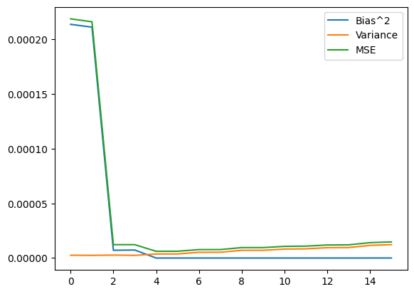

```python
import matplotlib.pyplot as plt
plt.plot(range(16), bias_squared, label="Bias^2")
plt.plot(range(16), variances, label="Variance")
plt.plot(range(16), mse, label="MSE")
plt.legend()
plt.show()
```

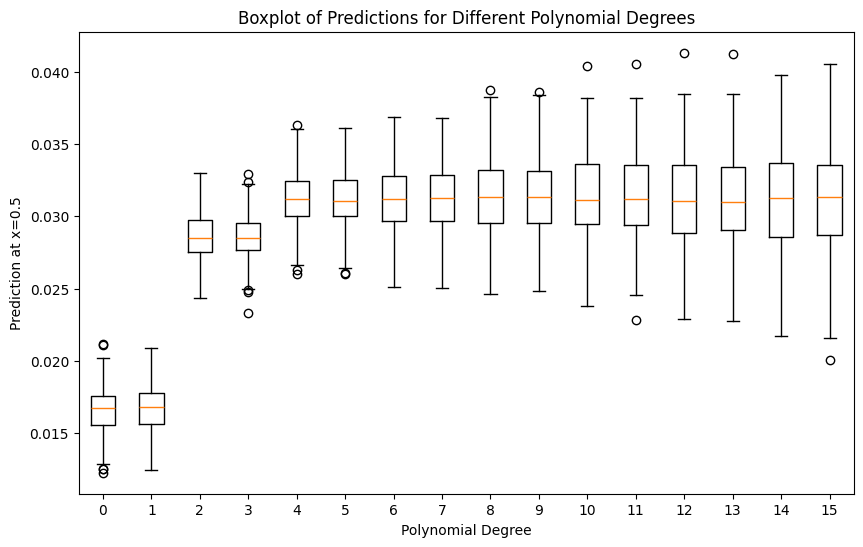

```python
# prompt: plot a box and whiskers plot to show all the 250 data points for the 16 polynomials to see the bias and variance

import matplotlib.pyplot as plt

# Assuming predictions_array from the previous code is available

plt.figure(figsize=(10, 6))  # Adjust figure size for better visualization
plt.boxplot(predictions_array, labels=range(16))
plt.xlabel("Polynomial Degree")
plt.ylabel("Prediction at x=0.5")
plt.title("Boxplot of Predictions for Different Polynomial Degrees")
plt.show()
```

**Question 4**

```python
!pip install ISLP
import pandas as pd
from ISLP import load_data
df = load_data('Auto')
df = df[df['horsepower'].notna()]
```

[output not shown]

[output cut: 27 more lines]

[output not shown]

```python
median_mpg = df['mpg'].median()

df['mpg01'] = (df['mpg'] > median_mpg).astype(int)

df
```

| name | mpg | cylinders | displacement | horsepower | weight | acceleration | year | origin | mpg01 |
| --- | --- | --- | --- | --- | --- | --- | --- | --- | --- |
| chevrolet chevelle malibu | 18.0 | 8 | 307.0 | 130 | 3504 | 12.0 | 70 | 1 | 0 |
| buick skylark 320 | 15.0 | 8 | 350.0 | 165 | 3693 | 11.5 | 70 | 1 | 0 |
| plymouth satellite | 18.0 | 8 | 318.0 | 150 | 3436 | 11.0 | 70 | 1 | 0 |
| amc rebel sst | 16.0 | 8 | 304.0 | 150 | 3433 | 12.0 | 70 | 1 | 0 |
| ford torino | 17.0 | 8 | 302.0 | 140 | 3449 | 10.5 | 70 | 1 | 0 |
| ... | ... | ... | ... | ... | ... | ... | ... | ... | ... |
| ford mustang gl | 27.0 | 4 | 140.0 | 86 | 2790 | 15.6 | 82 | 1 | 1 |
| vw pickup | 44.0 | 4 | 97.0 | 52 | 2130 | 24.6 | 82 | 2 | 1 |
| dodge rampage | 32.0 | 4 | 135.0 | 84 | 2295 | 11.6 | 82 | 1 | 1 |
| ford ranger | 28.0 | 4 | 120.0 | 79 | 2625 | 18.6 | 82 | 1 | 1 |
| chevy s-10 | 31.0 | 4 | 119.0 | 82 | 2720 | 19.4 | 82 | 1 | 1 |

392 rows × 9 columns

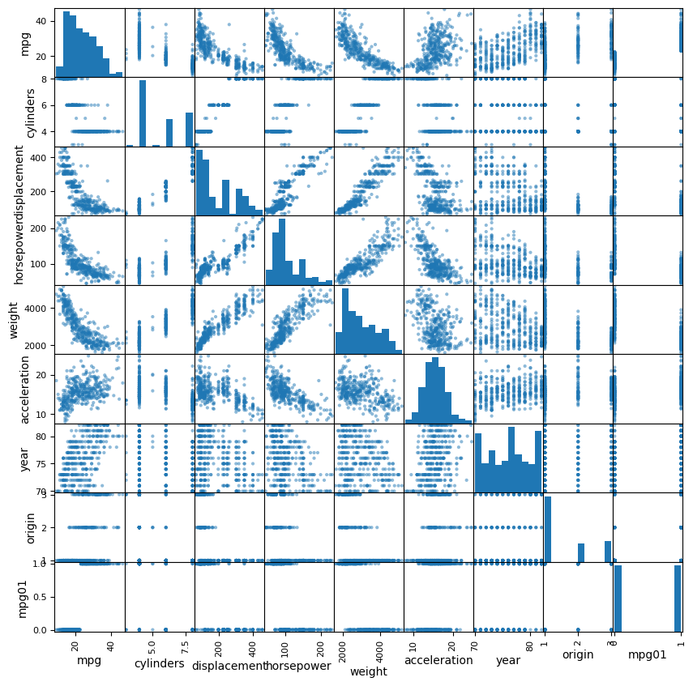

```python
pd.plotting.scatter_matrix(df, figsize=(10, 10))
plt.show()
```

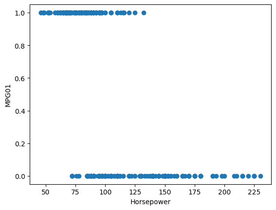

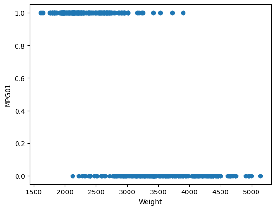

```python
plt.scatter(df['horsepower'], df['mpg01'])
plt.xlabel('Horsepower')
plt.ylabel('MPG01')
plt.show()


plt.scatter(df['weight'], df['mpg01'])
plt.xlabel('Weight')
plt.ylabel('MPG01')
plt.show()
```

After investigating, we believe that Horesepower and Weight are the two main features to predict MPG01.

**PART C**

```python
from sklearn.model_selection import train_test_split
```

```python
train, test = train_test_split(df, test_size=0.2, random_state=42)
```

**PART D**

```python
from sklearn.linear_model import LogisticRegression

X_train = train[['horsepower', 'cylinders', 'weight', 'displacement']]
y_train = train['mpg01']
X_test = test[['horsepower', 'cylinders', 'weight', 'displacement']]
y_test = test['mpg01']

model = LogisticRegression()
model.fit(X_train, y_train)

y_pred = model.predict(X_test)
error = y_test - y_pred
print("error: ", np.mean(error))
```

```
error:  -0.0759493670886076
```

**PART E**

```python
from sklearn.discriminant_analysis import LinearDiscriminantAnalysis as LDA

lda = LDA()
lda.fit(X_train, y_train)

y_pred = lda.predict(X_test)
error = y_test - y_pred
print("error: ", np.mean(error))
```

```
error:  -0.10126582278481013
```

**PART F**

```python
from sklearn.discriminant_analysis import QuadraticDiscriminantAnalysis as QDA

qda = QDA()
qda.fit(X_train, y_train)

y_pred = qda.predict(X_test)
error = y_test - y_pred
print("error: ", np.mean(error))
```

```
error:  -0.0759493670886076
```

**PART G**

```python
from sklearn.neighbors import KNeighborsClassifier

errors = []

for i in range(1, 20):
  knn = KNeighborsClassifier(n_neighbors=i)
  knn.fit(X_train, y_train)

  y_pred = knn.predict(X_test)
  error = y_test - y_pred
  errors.append(np.mean(error))
  print("error for ",i, " neighbors", np.mean(error))

np.min(np.abs(errors))

min_error_index = np.argmin(np.abs(errors))

print(f"The value of i with the lowest absolute error is: {min_error_index + 1}")
```

```
error for  1  neighbors -0.0379746835443038
error for  2  neighbors 0.02531645569620253
error for  3  neighbors -0.0759493670886076
error for  4  neighbors -0.012658227848101266
error for  5  neighbors -0.11392405063291139
error for  6  neighbors -0.10126582278481013
error for  7  neighbors -0.11392405063291139
error for  8  neighbors -0.11392405063291139
error for  9  neighbors -0.13924050632911392
error for  10  neighbors -0.11392405063291139
error for  11  neighbors -0.1518987341772152
error for  12  neighbors -0.11392405063291139
error for  13  neighbors -0.12658227848101267
error for  14  neighbors -0.11392405063291139
error for  15  neighbors -0.13924050632911392
error for  16  neighbors -0.13924050632911392
error for  17  neighbors -0.1518987341772152
error for  18  neighbors -0.1518987341772152
error for  19  neighbors -0.1518987341772152
The value of i with the lowest absolute error is: 4
```

**Question 5**

**PART A**

```python
import numpy as np
import matplotlib.pyplot as plt

def f(x):
  return x ** 5 - 2 * x ** 4 + x ** 3

np.random.seed(1)
x = np.random.uniform(0, 1, size=500)
y = f(x) + np.random.normal(0, 0.01, size=500)
```

**PART B**

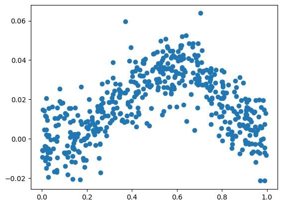

```python
plt.scatter(x,y)
```

**PART C**

```python
from ISLP import load_data
import statsmodels.api as sm
from ISLP.models import (ModelSpec as MS, summarize, poly)
from sklearn.model_selection import train_test_split
from functools import partial
from sklearn.model_selection import (cross_validate, KFold, ShuffleSplit)
from sklearn.base import clone
from ISLP.models import sklearn_sm
```

```python
np.random.seed(123)
cv_error = np.zeros(7)
H = np.array(x)
# if terms are not specified in sklean_sm, then sm.OLS uses all the columns in X without including an intercept term
M = sklearn_sm(sm.OLS)
for i, d in enumerate(range(0,7)):
    X = np.power.outer(H, np.arange(d+1))
    print(X.shape, d)
    M_CV = cross_validate(M, X, y, cv = 500) # n = 500
    cv_error[i] = np.mean(M_CV['test_score'])
cv_error
```

```
(500, 1) 0
(500, 2) 1
(500, 3) 2
(500, 4) 3
(500, 5) 4
(500, 6) 5
(500, 7) 6
```

```
array([0.00027279, 0.00025406, 0.00012947, 0.00011138, 0.00010207,
       0.00010134, 0.00010176])
```

**PART D**

```python
np.random.seed(12345)
cv_error = np.zeros(7)
H = np.array(x)
# if terms are not specified in sklean_sm, then sm.OLS uses all the columns in X without including an intercept term
M = sklearn_sm(sm.OLS)
for i, d in enumerate(range(0,7)):
    X = np.power.outer(H, np.arange(d+1))
    print(X.shape, d)
    M_CV = cross_validate(M, X, y, cv = 500) # n = 500
    cv_error[i] = np.mean(M_CV['test_score'])
cv_error
```

```
(500, 1) 0
(500, 2) 1
(500, 3) 2
(500, 4) 3
(500, 5) 4
(500, 6) 5
(500, 7) 6
```

```
array([0.00027279, 0.00025406, 0.00012947, 0.00011138, 0.00010207,
       0.00010134, 0.00010176])
```

Yes, the results are the same as part c. This is because LOOCV is non-random because every point is the test set one time, so the order of the points is irrelevant.

**PART E**

```python
np.min(cv_error)
```

```
0.00010134217412735225
```

**PART F**

```python
X_poly = np.column_stack([x**i for i in range(1, 6)])  # x, x^2, x^3, x^4, x^5
X_poly = sm.add_constant(X_poly)
results = sm.OLS(y, X_poly).fit()
print(results.summary())
```

```
                            OLS Regression Results
==============================================================================
Dep. Variable:                      y   R-squared:                       0.636
Model:                            OLS   Adj. R-squared:                  0.633
Method:                 Least Squares   F-statistic:                     173.0
Date:                Thu, 13 Feb 2025   Prob (F-statistic):          4.22e-106
Time:                        00:14:02   Log-Likelihood:                 1596.2
No. Observations:                 500   AIC:                            -3180.
Df Residuals:                     494   BIC:                            -3155.
Df Model:                           5
Covariance Type:            nonrobust
==============================================================================
                 coef    std err          t      P>|t|      [0.025      0.975]
------------------------------------------------------------------------------
const          0.0007      0.002      0.320      0.749      -0.004       0.005
x1            -0.0403      0.050     -0.799      0.424      -0.139       0.059
x2             0.2461      0.325      0.758      0.449      -0.392       0.884
x3             0.5078      0.837      0.607      0.544      -1.137       2.152
x4            -1.6168      0.930     -1.739      0.083      -3.444       0.210
x5             0.9050      0.372      2.435      0.015       0.175       1.635
==============================================================================
Omnibus:                        1.684   Durbin-Watson:                   2.027
Prob(Omnibus):                  0.431   Jarque-Bera (JB):                1.591
Skew:                           0.000   Prob(JB):                        0.451
Kurtosis:                       3.276   Cond. No.                     3.87e+03
==============================================================================

Notes:
[1] Standard Errors assume that the covariance matrix of the errors is correctly specified.
[2] The condition number is large, 3.87e+03. This might indicate that there are
strong multicollinearity or other numerical problems.
```

```python
!sudo apt-get install texlive-xetex texlive-fonts-recommended texlive-plain-generic pandoc

from google.colab import drive
drive.mount('/content/drive')
```

[output not shown]

[output cut: 348 more lines]

[output not shown]